# R Notebook

```r
anova(z3,test="Chisq")
```

|  | Df | Deviance | Resid. Df | Resid. Dev | Pr(>Chi) |
| --- | --- | --- | --- | --- | --- |
| NULL | NA | NA | 172 | 213.0460 | NA |
| width.cm | 1 | 17.23475 | 171 | 195.8112 | 3.303384e-05 |

```r
summary(z3)
```

```
##
## Call:
## glm.nb(formula = nsatellites ~ width.cm, data = x, init.theta = 0.90456808,
##     link = log)
##
## Deviance Residuals:
##     Min       1Q   Median       3Q      Max
## -1.7798  -1.4110  -0.2502   0.4770   2.0177
##
## Coefficients:
##             Estimate Std. Error z value Pr(>|z|)
## (Intercept) -4.05251    1.17143  -3.459 0.000541 ***
## width.cm     0.19207    0.04406   4.360  1.3e-05 ***
## ---
## Signif. codes:  0 '***' 0.001 '**' 0.01 '*' 0.05 '.' 0.1 ' ' 1
##
## (Dispersion parameter for Negative Binomial(0.9046) family taken to be 1)
##
##     Null deviance: 213.05  on 172  degrees of freedom
## Residual deviance: 195.81  on 171  degrees of freedom
## AIC: 757.29
##
## Number of Fisher Scoring iterations: 1
##
##
##               Theta:  0.905
##           Std. Err.:  0.161
##
##  2 x log-likelihood:  -751.291
```

```r
gof(z3)
```

```
## D  = 195.8112, df = 171, P(>D) = 0.09385484
## X2 = 144.7507, df = 171, P(>X2) = 0.9282352
```

```r
#The negative binomial distribution dispersion paramter is closest to 1. Variance = dispersion parameter * mean.
```

How do the regression coefficients of this new fit compare with the estimates from the earlier model fit? How do the standard errors compare? If there are differences why?

```r
#The coefficients from the old model fit are as follows:

#Coefficients:
            #Estimate Std. Error z value Pr(>|z|)
#(Intercept) -3.30476    0.54224  -6.095  1.1e-09 ***
#width.cm     0.16405    0.01997   8.216  < 2e-16 ***


#The coefficients from the new fit are:

#Coefficients:
            #Estimate Std. Error t value Pr(>|t|)
#(Intercept) -3.30476    0.96729  -3.417 0.000793 ***
#width.cm     0.16405    0.03562   4.606 7.99e-06 ***

#The coefficient values are the same but the standard deviation is larger.
```

Visualize the new model fit and compare with the plot of the earlier fit. What difference do you notice?

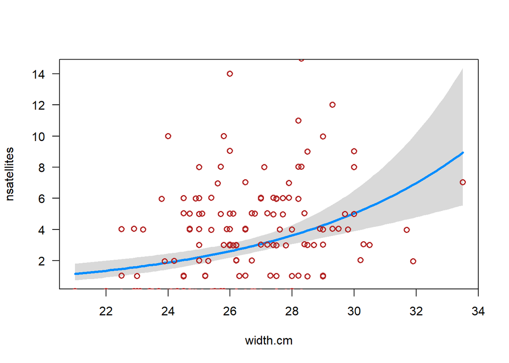

```r
visreg(z2, xvar = "width.cm", scale = "response", rug = FALSE)
points(jitter(nsatellites, 0.2) ~ width.cm, data = x, pch = 1,
    col = "firebrick", lwd = 1.5)
```

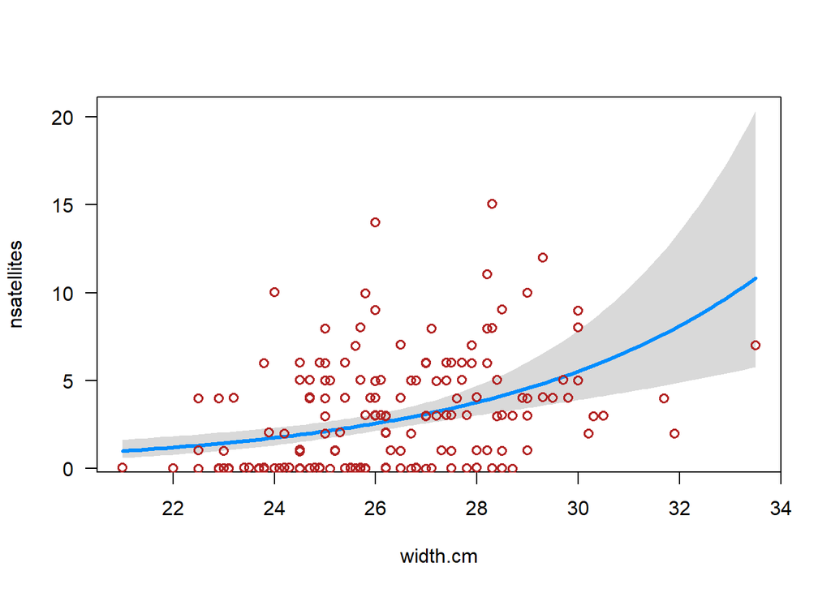

```r
visreg(z3, xvar = "width.cm", scale = "response", rug = FALSE)
points(jitter(nsatellites, 0.2) ~ width.cm, data = x, pch = 1,
    col = "firebrick", lwd = 1.5)
```

```r
#The standard error is larger and the points are more concentrated.
```

10. Redo the test of significance for the slope of the relationship between number of satellite mates and female carapace width. Remember if you chose to use a quasi distribution you have to use the F test rather than the likelihood ratio test in the anova command. How do the results compare with those from the previous fit?

```r
anova(z2, test = "F")
```

|  | Df | Deviance | Resid. Df | Resid. Dev | F | Pr(>F) |
| --- | --- | --- | --- | --- | --- | --- |
| NULL | NA | NA | 172 | 632.7917 | NA | NA |
| width.cm | 1 | 64.91309 | 171 | 567.8786 | 20.39878 | 1.167798e-05 |

```r
anova(z3, test = "Chisq")
```

|  | Df | Deviance | Resid. Df | Resid. Dev | Pr(>Chi) |
| --- | --- | --- | --- | --- | --- |
| NULL | NA | NA | 172 | 213.0460 | NA |
| width.cm | 1 | 17.23475 | 171 | 195.8112 | 3.303384e-05 |

```r
#The p-value is larger here (more-likely).
```